# **Milestone 2**

# **Part III: Conclusions**

### **Best Model**

Lets choose the model with the best accuracy scores from all the above models and save it as a final model.

- After several experiments, it seems that all model perform similarly around 90 to 95% accuracy. More complex models (VGG16) do not necessarily result in increased performances. Our best model architecture is therefore CNN5, because of its fast computation. This is a very deep CNN (5 conv2D layers and 4 fully-connected layers), but with little trainable parameters (around 400 000 instead of a million for the base model CNN0).
- As regards to feature engineering, we have obtained best results (+1% accuracy) whith data augmentation using rotations +90,+180,+170 with/without horizontal flip. These are "natural" transformations that could occur randomly in the experimental process. Other feature engineering (HSV conversion, change of border colors...) did not result in performance improvements.

### **Observations and Conclusions drawn from the final model:**

**Improvements that can be done:**

- Can the model performance be improved using other pre-trained models or different CNN architecture?
- You can try to build a model using these HSV images and compare them with your other models.

### **Insights**

**1.** What are the most meaningful insights from the data relevant to the problem?

**2. Comparison of various techniques and their relative performance:** How do different techniques perform? Which one is performing relatively better? Is there scope to improve the performance further?

**3. Proposal for the final solution design:** What model do you propose to be adopted? Why is this the best solution to adopt?

**4. Key recommendations for implementation:** What are some key recommendations to implement the solutions? What should the implementation roadmap look like? What further analysis needs to be done or what other associated problems need to be solved?

**Note:** the discussion on insights is provided in the Report for Milestone 2.

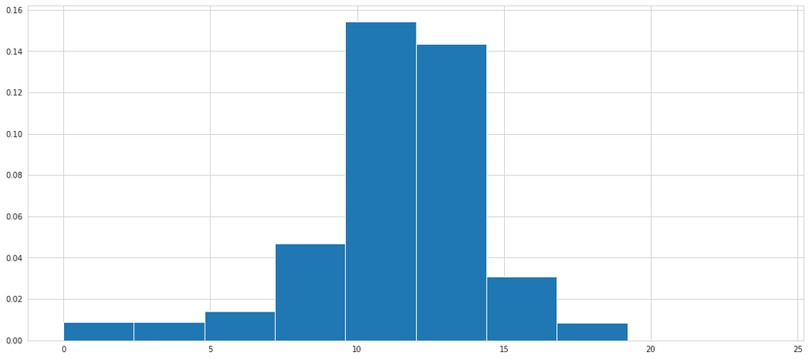

```python
# Computation of rule of thumb for practical diagnosis (where several red cells are sampled)


import random
import matplotlib.pyplot as plt
import seaborn as sns
sns.set_style('whitegrid')
import numpy as np

# compute empirically the distribution of counts of parasitized cell counts given the 95pct accuracy
R=10000# number of random tests (ensemble method)
Rcount=[]# meta list of counts
#
# N=1000# number of cells analyzed
N=100# number of cells analyzed
# N=10# number of cells analyzed

Mper=0.1# percentage of infected cells
M=int(N*Mper)# true number of parasitized cells
p=0.05# error of model

for r in range(R):
  count=0# count of parasitized cells from model
  for i in range(N):
    parasitized=i<M# true state
    a=random.uniform(0, 1)
    if a>p:# no error
      if parasitized:
        count += 1# correct count of a parasitizeds
    else:
      if not parasitized:
        count+=1# wrong count (False Negative)
      else:
        pass# not counting a real parasitized
    Rcount.append(count)

# print(Rcount)
# Rcount=Rcount/N# count in percentage
plt.figure(None, figsize = (18 , 8))
plt.hist(Rcount,density=True)

# Save one
# Rcount1k=Rcount# 1000 samples
Rcount100=Rcount# 100 samples
# Rcount10=Rcount# 10 samples
```

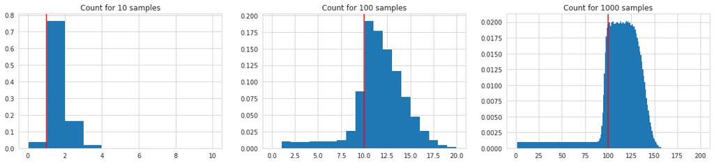

```python
plt.figure(None, figsize = (20 , 4))
plt.subplot(1,3,1)
plt.hist(Rcount10, density=True,bins=range(11),histtype='stepfilled')
plt.axvline(x=1,color='r')
plt.title('Count for 10 samples')
plt.subplot(1,3,2)
plt.hist(Rcount100, density=True,bins=range(21),histtype='stepfilled')
plt.axvline(x=10,color='r')
plt.title('Count for 100 samples')
plt.subplot(1,3,3)
plt.hist(Rcount1k, density=True,bins=range(201),histtype='stepfilled')
plt.axvline(x=100,color='r')
plt.title('Count for 1000 samples')
```